# Imports

```python
import pandas as pd
import numpy as np
import matplotlib.pyplot as plt
from tqdm.notebook import tqdm
from sklearn.linear_model import LinearRegression
from sklearn.tree import DecisionTreeClassifier
from sklearn.ensemble import RandomForestClassifier
from sklearn.tree import export_graphviz
import tensorflow
from tensorflow.keras import Model, layers
import sklearn.neural_network
from six import StringIO
from IPython.display import Image
import pydotplus
```

# Summary

## Eolution of the strategies

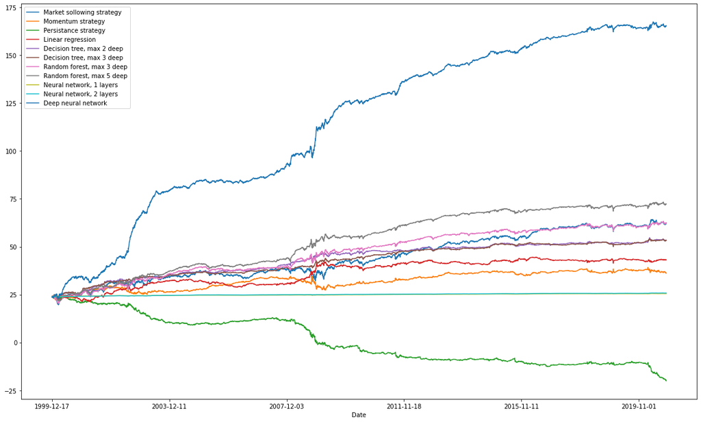

```python
portfolioDF.plot()
plt.show()
```

## Table with the values of the strategies

```python
evolutionTable
```

| Day | Market following strategy | Momentum strategy | Persistance strategy | Linear regression | Decision tree, max 2 deep | Decision tree, max 3 deep | Random forest, max 3 deep | Random forest, max 5 deep | Neural network, 1 layers | Neural network, 2 layers | Deep neural network |
| --- | --- | --- | --- | --- | --- | --- | --- | --- | --- | --- | --- |
| 0 | 24.00 | 24.00 | 24.00 | 24.00 | 24.00 | 24.00 | 24.00 | 24.00 | 24.00 | 24.00 | 24.00 |
| 250 | 25.69 | 25.84 | 20.63 | 21.86 | 24.81 | 26.17 | 25.45 | 26.38 | 24.25 | 24.09 | 34.63 |
| 500 | 31.31 | 29.35 | 20.34 | 25.38 | 32.25 | 31.87 | 28.68 | 28.99 | 24.44 | 24.37 | 40.51 |
| 750 | 31.41 | 26.10 | 15.59 | 28.42 | 33.75 | 33.92 | 32.90 | 34.61 | 24.47 | 24.38 | 65.55 |
| 1000 | 34.33 | 26.28 | 10.39 | 32.14 | 35.38 | 35.02 | 35.88 | 37.16 | 24.57 | 24.61 | 79.68 |
| 1250 | 37.08 | 27.68 | 9.67 | 32.17 | 36.99 | 36.77 | 39.40 | 41.33 | 24.69 | 24.85 | 84.42 |
| 1500 | 35.26 | 30.40 | 10.37 | 29.77 | 37.39 | 36.50 | 37.89 | 40.02 | 24.68 | 24.84 | 84.17 |
| 1750 | 36.68 | 33.42 | 11.76 | 30.03 | 38.39 | 37.34 | 38.76 | 41.50 | 24.71 | 24.88 | 85.81 |
| 2000 | 38.16 | 33.23 | 11.34 | 30.65 | 40.68 | 39.05 | 39.78 | 44.01 | 24.80 | 25.00 | 93.08 |
| 2250 | 35.40 | 29.46 | 1.11 | 38.70 | 45.29 | 41.85 | 45.41 | 52.65 | 24.82 | 24.99 | 109.30 |
| 2500 | 42.81 | 29.72 | -2.76 | 40.29 | 46.61 | 43.62 | 48.60 | 55.51 | 24.95 | 25.12 | 125.69 |
| 2750 | 42.74 | 31.41 | -5.64 | 39.39 | 48.05 | 45.71 | 50.35 | 57.21 | 25.01 | 25.17 | 127.59 |
| 3000 | 46.47 | 32.82 | -7.44 | 41.41 | 47.64 | 47.72 | 52.49 | 61.29 | 25.11 | 25.27 | 135.85 |
| 3250 | 48.07 | 34.31 | -8.87 | 42.11 | 48.20 | 47.90 | 54.11 | 63.59 | 25.14 | 25.29 | 139.51 |
| 3500 | 52.95 | 36.22 | -9.05 | 41.40 | 49.99 | 49.30 | 57.08 | 67.49 | 25.26 | 25.43 | 145.24 |
| 3750 | 55.04 | 37.08 | -8.97 | 42.50 | 50.90 | 50.70 | 57.94 | 68.71 | 25.32 | 25.47 | 151.63 |
| 4000 | 55.13 | 35.89 | -10.01 | 43.46 | 50.70 | 51.25 | 57.61 | 68.08 | 25.31 | 25.51 | 153.50 |
| 4250 | 58.60 | 36.55 | -12.11 | 43.19 | 50.77 | 51.12 | 58.41 | 69.52 | 25.42 | 25.62 | 158.35 |
| 4500 | 61.01 | 38.27 | -11.19 | 42.54 | 52.14 | 51.49 | 60.93 | 71.23 | 25.50 | 25.69 | 161.52 |
| 4750 | 60.31 | 37.26 | -11.31 | 43.01 | 51.73 | 51.45 | 60.48 | 70.57 | 25.48 | 25.66 | 164.47 |
| 5000 | 60.68 | 37.71 | -10.55 | 43.23 | 52.14 | 52.21 | 60.37 | 71.08 | 25.49 | 25.67 | 164.25 |

## Table with the strategies performance measures

```python
performanceTable.astype(float).round(3)
```

| Measure | Market following strategy | Momentum strategy | Persistance strategy | Linear regression | Decision tree, max 2 deep | Decision tree, max 3 deep | Random forest, max 3 deep | Random forest, max 5 deep | Neural network, 1 layers | Neural network, 2 layers | Deep neural network |
| --- | --- | --- | --- | --- | --- | --- | --- | --- | --- | --- | --- |
| Annualized means | 1.840 | 0.586 | -2.117 | 0.918 | 1.425 | 1.405 | 1.864 | 2.329 | 0.075 | 0.089 | 6.816 |
| Annualized volatility | 3.606 | 2.236 | 2.294 | 1.965 | 1.599 | 1.468 | 2.647 | 2.507 | 0.105 | 0.110 | 3.583 |
| Sharpe ratio | 0.510 | 0.262 | -0.923 | 0.467 | 0.891 | 0.957 | 0.704 | 0.929 | 0.717 | 0.807 | 1.902 |
| Win percentage [%] | 54.431 | 53.170 | 49.503 | 50.162 | 51.862 | 51.500 | 53.524 | 54.002 | 54.117 | 54.250 | 57.746 |
| Average precision [%] | 51.491 | 50.336 | 48.865 | 49.797 | 50.208 | 50.264 | 50.664 | 50.817 | 50.490 | 50.513 | 53.290 |

# Main

```python
# DJ Data
data = pd.read_csv('DowJones_daily.csv', sep = ',', parse_dates=True)
data = data.set_index('Date')
benchmark = data.iloc[1001:]
tickers = data.columns
```

```python
ewm = data.iloc[980:].ewm(span = 20, adjust = False).mean().iloc[20:-1].to_numpy()
benchmarkNP = benchmark.to_numpy()
initInvest = 1
```

```python
strategies = [
    'Market following strategy', 'Momentum strategy', 'Persistance strategy',
    'Linear regression','Decision tree, max 2 deep', 'Decision tree, max 3 deep',
    'Random forest, max 3 deep', 'Random forest, max 5 deep',
    'Neural network, 1 layers', 'Neural network, 2 layers',
    'Deep neural network'
    ]
performanceMeasures = [
    'Annualized means', 'Annualized volatility',
    'Sharpe ratio', 'Win percentage', 'Average precision [%]'
    ]
```

# 1. Benchmark strategies

### Market following strategy

```python
portfolioReturns = np.zeros((len(benchmark), 3))
averagePrecision = []
```

```python
value = np.zeros((len(benchmark),len(tickers)))
avg = np.zeros(len(benchmark))

for x in range(len(benchmark)):
    value[x, :] = 1 * benchmark.iloc[x, :]
    count = (benchmark.iloc[x, :] >= 0).sum()
    avg[x] = count / len(tickers)
    portfolioReturns[x, 0] = np.sum(value[x, :])

averagePrecision.append(np.mean(avg))
```

### Momentum strategy

```python
val = np.zeros((len(ewm), len(tickers)))
avg = np.zeros(len(ewm))

for i, x in enumerate(ewm):
    if i != len(ewm):
        for j, y in enumerate(x):
            if y >= 0:
                val[i,j] = 1 * benchmarkNP[i,j]
            elif y < 0:
                val[i,j] = -1 * benchmarkNP[i,j]
        count = (val[i,:] > 0).sum()
        avg[i] = count / len(tickers)
        portfolioReturns[i,1] = np.sum(val[i, :])

averagePrecision.append(np.mean(avg))
```

### Persistance strategy

```python
persist = data.iloc[1000:].to_numpy()
val = np.zeros((len(benchmark), 24))
avg = np.zeros(len(benchmark))

for i, p in enumerate(persist):
    if i != len(benchmark):
        for j, y in enumerate(p):
            if y >= 0:
                val[i,j] = 1 * benchmarkNP[i,j]
            elif y < 0:
                val[i,j] = -1 * benchmarkNP[i,j]
        count = (val[i, :] > 0).sum()
        avg[i] = count / len(tickers)
        portfolioReturns[i,2] = np.sum(val[i, :])

averagePrecision.append(np.mean(avg))
```

```python
portfolio = np.zeros((len(benchmark), 3))
startVal = len(tickers) * initInvest
portfolio[:, 0] = startVal + np.cumsum(portfolioReturns[:, 0])
portfolio[:, 1] = startVal + np.cumsum(portfolioReturns[:, 1])
portfolio[:, 2] = startVal + np.cumsum(portfolioReturns[:, 2])
portfolioDF = pd.DataFrame(
    portfolio, index = benchmark.index,
    columns = ['Market sollowing strategy','Momentum strategy', 'Persistance strategy']
    )
```

## a) Plot the evolution of the strategies

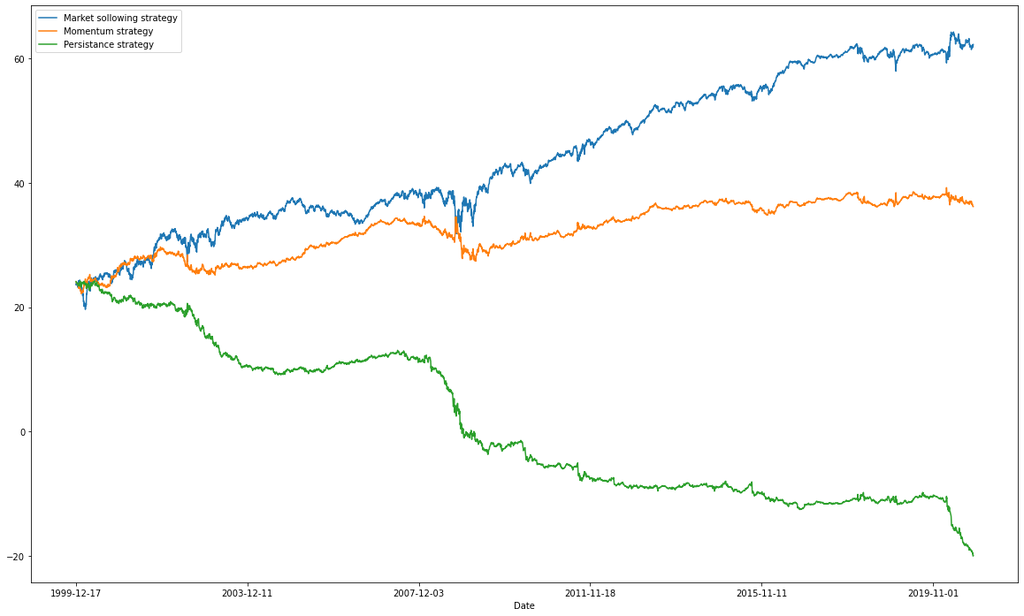

```python
plt.rcParams["figure.figsize"] = (20,12)
portfolioDF.plot()
plt.show()
```

## b) Table with the values of the strategies

```python
idx = np.linspace(0,5000,21).astype(int)
evolutionTable_dict = {
  'Market following strategy': [startVal if val == 0 else portfolioDF.iloc[250 * val, 0] for val in range(len(idx))],
  'Momentum strategy': [startVal if val == 0 else portfolioDF.iloc[250 * val, 1] for val in range(len(idx))],
  'Persistance strategy': [startVal if val == 0 else portfolioDF.iloc[250 * val, 2] for val in range(len(idx))]
}

evolutionTable = pd.DataFrame(evolutionTable_dict, index = idx).round(2)
evolutionTable.index.name = 'Day'
evolutionTable
```

| Day | Market following strategy | Momentum strategy | Persistance strategy |
| --- | --- | --- | --- |
| 0 | 24.00 | 24.00 | 24.00 |
| 250 | 25.69 | 25.84 | 20.63 |
| 500 | 31.31 | 29.35 | 20.34 |
| 750 | 31.41 | 26.10 | 15.59 |
| 1000 | 34.33 | 26.28 | 10.39 |
| 1250 | 37.08 | 27.68 | 9.67 |
| 1500 | 35.26 | 30.40 | 10.37 |
| 1750 | 36.68 | 33.42 | 11.76 |
| 2000 | 38.16 | 33.23 | 11.34 |
| 2250 | 35.40 | 29.46 | 1.11 |
| 2500 | 42.81 | 29.72 | -2.76 |
| 2750 | 42.74 | 31.41 | -5.64 |
| 3000 | 46.47 | 32.82 | -7.44 |
| 3250 | 48.07 | 34.31 | -8.87 |
| 3500 | 52.95 | 36.22 | -9.05 |
| 3750 | 55.04 | 37.08 | -8.97 |
| 4000 | 55.13 | 35.89 | -10.01 |
| 4250 | 58.60 | 36.55 | -12.11 |
| 4500 | 61.01 | 38.27 | -11.19 |
| 4750 | 60.31 | 37.26 | -11.31 |
| 5000 | 60.68 | 37.71 | -10.55 |

```python
portfolioReturns = portfolioReturns.T
annualizedMeans = []
annualizedVol = []
sharpeRatios = []
winPrc = []

# Annualized annualizedMeans
for i in range(len(strategies[:3])):
    annualizedMeans.append(np.mean(portfolioReturns[i]) * 252)


# Annualized volatilities
for i in range(len(strategies[:3])):
    annualizedVol.append(np.std(portfolioReturns[i]) * np.sqrt(252))


# Sharpe Ratios
for i in range(len(strategies[:3])):
    sharpeRatios.append(np.mean(portfolioReturns[i]) / np.std(portfolioReturns[i]) * np.sqrt(252))


# Win percentage
for i in range(len(strategies[:3])):
    count = 0
    for v in portfolioReturns[i]:
        if v >= 0:
            count += 1
    winPrc.append(count / len(portfolioReturns[i]))
```

## c) Table showing the strategies performance measures

```python
performanceTable = pd.DataFrame([])

for i in range(len(strategies[:3])):
    performanceTable[strategies[i]] = pd.Series({
        'Annualized means': annualizedMeans[i],
        'Annualized volatility': annualizedVol[i],
        'Sharpe ratio': sharpeRatios[i],
        'Win percentage [%]': winPrc[i] * 100,
        'Average precision [%]': averagePrecision[i] * 100
    })
performanceTable.index.name = 'Measure'
performanceTable.astype(float).round(3)
```

| Measure | Market following strategy | Momentum strategy | Persistance strategy |
| --- | --- | --- | --- |
| Annualized means | 1.840 | 0.586 | -2.117 |
| Annualized volatility | 3.606 | 2.236 | 2.294 |
| Sharpe ratio | 0.510 | 0.262 | -0.923 |
| Win percentage [%] | 54.431 | 53.170 | 49.503 |
| Average precision [%] | 51.491 | 50.336 | 48.865 |

## Discussion:

During the test period the market following strategy performs the best in terms of return, Sharpe ratio, win percentage. Logically, since good precition should increase performance, it also had the best accuracy in predicting forward return sign (precision). The only negative is the high volatility, if one are concerned with a stable portfolio.

# 2. Linear regression and decision tree strategies

```python
# Signals
ewm20 = data.ewm(span = 20).mean()
ewm60 = data.ewm(span = 60).mean()
ewm20.columns = [stock + ' EWMA(20)' for stock in tickers]
ewm60.columns = [stock + ' EWMA(60)' for stock in tickers]
ewm = pd.concat([ewm20, ewm60], axis = 1)
ewm = ewm[list(sum(zip(ewm20.columns, ewm60.columns), ()))]

x = np.array(ewm)
y = np.array(data.iloc[1:])
```

### Linnear regression

```python
tmp = np.zeros((250, len(tickers)))
returns = np.zeros(len(benchmark))
avg = np.zeros(len(benchmark))
count = 0

for i in range(len(idx)):

    # Training Data
    if i == 0:
        trainX, testX = x[:1000], x[1000:1250]
        trainY, testY = y[:1000], y[1000:1250]
    elif i == 20:
        trainX, testX = x[250*i:1000+250*i], x[1000+250*i: 1236+250*i]
        trainY, testY = y[250*i:1000+250*i], y[1000+250*i: 1236+250*i]
    else:
        trainX, testX = x[250*i:1000+250*i], x[1000+250*i: 1250+250*i]
        trainY, testY = y[250*i:1000+250*i], y[1000+250*i: 1250+250*i]

    # Train Model
    model = LinearRegression()
    model.fit(trainX, trainY) # Train model
    predictY = model.predict(testX) # Predict

    for j, pred in enumerate(predictY):
        for k, val in enumerate(pred):
            if val >= 0:
                tmp[j, k] = 1 * testY[j, k]
            else:
                tmp[j, k] = - 1 * testY[j, k]

        avg[count] = (tmp[j,:] > 0).sum() / startVal
        returns[count] = np.sum(tmp[j,:])
        count += 1

averagePrecision.append(np.mean(avg))
portfolioDF['Linear regression'] = startVal + np.cumsum(returns)
```

### Decision trees

```python
# 3 deep
depth = 2

tmp = np.zeros((250, len(tickers)))
returns = np.zeros(len(benchmark))
avg = np.zeros(len(benchmark))
count = 0

for i in range(len(idx)):

    # Training data
    if i == 0:
        trainX, testX = x[:1000], x[1000:1250]
        trainY, testY = y[:1000], y[1000:1250]
    elif i == 20:
        trainX, testX = x[250*i:1000 + 250*i], x[1000 + 250*i: 1236 + 250*i]
        trainY, testY = y[250*i:1000 + 250*i], y[1000 + 250*i: 1236 + 250*i]
    else:
        trainX, testX = x[250*i:1000 + 250*i], x[1000 + 250*i: 1250 + 250*i]
        trainY, testY = y[250*i:1000 + 250*i], y[1000 + 250*i: 1250 + 250*i]

    # Training Model
    predictY = np.zeros((testY.shape[0], testY.shape[1]))
    trainYTree = np.sign(trainY)
    trainYTree[trainYTree == 0] = 1
    modelDT = DecisionTreeClassifier(max_depth=depth)
    for ti in range(len(tickers)):
        modelDT.fit(trainX, trainYTree[:, ti]) # Train model
        predictY[:, ti] = modelDT.predict(testX) # Predict
        if ti == 0:
            AAPL = DecisionTreeClassifier(max_depth = 2)
            AAPL.fit(trainX, trainYTree[:, ti])

    ret = np.sum(predictY * testY, axis = 1)
    for j in range(len(predictY)):
        tmp = predictY[j] * testY[j]
        avg[count] = (tmp > 0).sum() / 24
        count += 1

    returns[250*i: 250*i + 250] = ret

averagePrecision.append(np.mean(avg))
portfolioDF['Decision tree, max 2 deep'] = startVal + np.cumsum(returns)
```

```python
# 3 deep
depth = 3

tmp = np.zeros((250, len(tickers)))
returns = np.zeros(len(benchmark))
avg = np.zeros(len(benchmark))
count = 0

for i in range(len(idx)):

    # Training data
    if i == 0:
        trainX, testX = x[:1000], x[1000:1250]
        trainY, testY = y[:1000], y[1000:1250]
    elif i == 20:
        trainX, testX = x[250*i:1000+250*i], x[1000+250*i: 1236+250*i]
        trainY, testY = y[250*i:1000+250*i], y[1000+250*i: 1236+250*i]
    else:
        trainX, testX = x[250*i:1000+250*i], x[1000+250*i: 1250+250*i]
        trainY, testY = y[250*i:1000+250*i], y[1000+250*i: 1250+250*i]

    predictY = np.zeros((testY.shape[0], testY.shape[1]))
    trainYTree = np.sign(trainY)
    trainYTree[trainYTree == 0] = 1
    modelDT = DecisionTreeClassifier(max_depth=depth)
    for ti in range(len(tickers)):
        modelDT.fit(trainX, trainYTree[:, ti])  # Train model
        predictY[:, ti] = modelDT.predict(testX) # Predict

    ret = np.sum(predictY * testY, axis = 1)
    for j in range(len(predictY)):
        tmp = predictY[j] * testY[j]
        avg[count] = (tmp > 0).sum() / startVal
        count += 1

    returns[250*i: 250*i+250] = ret

averagePrecision.append(np.mean(avg))
portfolioDF['Decision tree, max 3 deep'] = startVal + np.cumsum(returns)
```

## a) Plot the evolution of the strategies

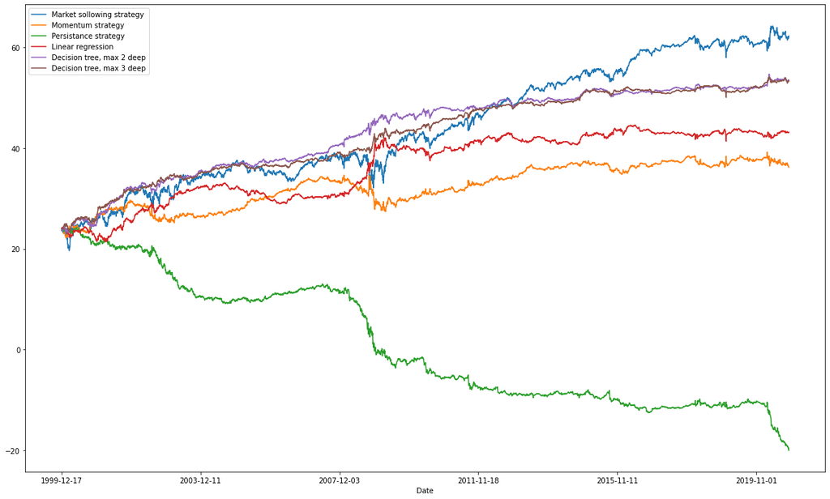

```python
portfolioDF.plot()
plt.show()
```

## b) Table with the values of the strategies

```python
evolutionTable_dict['Linear regression'] = [startVal if val == 0 else portfolioDF.iloc[250 * val, strategies.index('Linear regression')] for val in range(len(idx))]
evolutionTable_dict['Decision tree, max 2 deep'] = [startVal if val == 0 else portfolioDF.iloc[250 * val, strategies.index('Decision tree, max 2 deep')] for val in range(len(idx))]
evolutionTable_dict['Decision tree, max 3 deep'] = [startVal if val == 0 else portfolioDF.iloc[250 * val, strategies.index('Decision tree, max 3 deep')] for val in range(len(idx))]

evolutionTable = pd.DataFrame(evolutionTable_dict, index = idx).round(2)
evolutionTable.index.name = 'Day'
evolutionTable
```

| Day | Market following strategy | Momentum strategy | Persistance strategy | Linear regression | Decision tree, max 2 deep | Decision tree, max 3 deep |
| --- | --- | --- | --- | --- | --- | --- |
| 0 | 24.00 | 24.00 | 24.00 | 24.00 | 24.00 | 24.00 |
| 250 | 25.69 | 25.84 | 20.63 | 21.86 | 24.81 | 26.17 |
| 500 | 31.31 | 29.35 | 20.34 | 25.38 | 32.25 | 31.87 |
| 750 | 31.41 | 26.10 | 15.59 | 28.42 | 33.75 | 33.92 |
| 1000 | 34.33 | 26.28 | 10.39 | 32.14 | 35.38 | 35.02 |
| 1250 | 37.08 | 27.68 | 9.67 | 32.17 | 36.99 | 36.77 |
| 1500 | 35.26 | 30.40 | 10.37 | 29.77 | 37.39 | 36.50 |
| 1750 | 36.68 | 33.42 | 11.76 | 30.03 | 38.39 | 37.34 |
| 2000 | 38.16 | 33.23 | 11.34 | 30.65 | 40.68 | 39.05 |
| 2250 | 35.40 | 29.46 | 1.11 | 38.70 | 45.29 | 41.85 |
| 2500 | 42.81 | 29.72 | -2.76 | 40.29 | 46.61 | 43.62 |
| 2750 | 42.74 | 31.41 | -5.64 | 39.39 | 48.05 | 45.71 |
| 3000 | 46.47 | 32.82 | -7.44 | 41.41 | 47.64 | 47.72 |
| 3250 | 48.07 | 34.31 | -8.87 | 42.11 | 48.20 | 47.90 |
| 3500 | 52.95 | 36.22 | -9.05 | 41.40 | 49.99 | 49.30 |
| 3750 | 55.04 | 37.08 | -8.97 | 42.50 | 50.90 | 50.70 |
| 4000 | 55.13 | 35.89 | -10.01 | 43.46 | 50.70 | 51.25 |
| 4250 | 58.60 | 36.55 | -12.11 | 43.19 | 50.77 | 51.12 |
| 4500 | 61.01 | 38.27 | -11.19 | 42.54 | 52.14 | 51.49 |
| 4750 | 60.31 | 37.26 | -11.31 | 43.01 | 51.73 | 51.45 |
| 5000 | 60.68 | 37.71 | -10.55 | 43.23 | 52.14 | 52.21 |

```python
dailyReturns = []

# Daily returns
for s in strategies[3:6]:
    dailyReturns.append(portfolioDF[s].to_numpy()[1:] - portfolioDF[s].shift(1).dropna().to_numpy())


# Annualized annualizedMeans
for i in range(len(dailyReturns)):
    annualizedMeans.append(np.mean(dailyReturns[i]) * 252)


# Annualized volatilities
for i in range(len(dailyReturns)):
    annualizedVol.append(np.std(dailyReturns[i]) * np.sqrt(252))


# Sharpe Ratios
for i in range(len(dailyReturns)):
    sharpeRatios.append(np.mean(dailyReturns[i]) / np.std(dailyReturns[i]) * np.sqrt(252))


# Win percentage
for i in range(len(dailyReturns)):
    count = 0
    for v in dailyReturns[i]:
        if v >= 0:
            count += 1
    winPrc.append(count / len(dailyReturns[i]))
```

## c) Table showing the strategies performance measures

```python
for i, s in enumerate(strategies[3:6]):
    i = i+3

    performanceTable[s] = pd.Series({
        'Annualized means': annualizedMeans[i],
        'Annualized volatility': annualizedVol[i],
        'Sharpe ratio': sharpeRatios[i],
        'Win percentage [%]': winPrc[i] * 100,
        'Average precision [%]': averagePrecision[i] * 100
    })
performanceTable.index.name = 'Measure'
performanceTable.astype(float).round(3)
```

| Measure | Market following strategy | Momentum strategy | Persistance strategy | Linear regression | Decision tree, max 2 deep | Decision tree, max 3 deep |
| --- | --- | --- | --- | --- | --- | --- |
| Annualized means | 1.840 | 0.586 | -2.117 | 0.918 | 1.425 | 1.405 |
| Annualized volatility | 3.606 | 2.236 | 2.294 | 1.965 | 1.599 | 1.468 |
| Sharpe ratio | 0.510 | 0.262 | -0.923 | 0.467 | 0.891 | 0.957 |
| Win percentage [%] | 54.431 | 53.170 | 49.503 | 50.162 | 51.862 | 51.500 |
| Average precision [%] | 51.491 | 50.336 | 48.865 | 49.797 | 50.208 | 50.264 |

## d) Decision tree for Apple, maximum depth 2

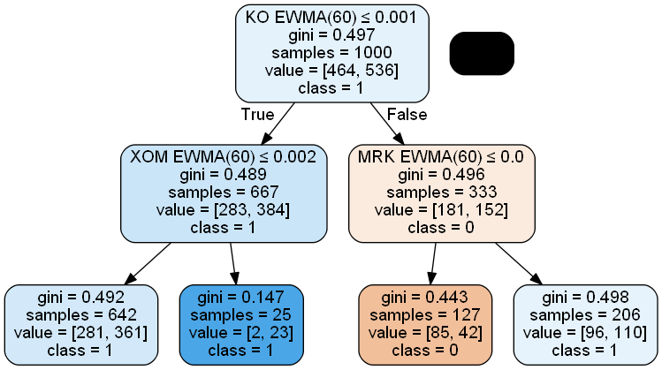

```python
dot_data = StringIO()
export_graphviz(AAPL, out_file = dot_data, filled = True, rounded = True,
special_characters = True, feature_names = ewm.columns, class_names = ['0', '1'])
graph = pydotplus.graph_from_dot_data(dot_data.getvalue())
graph.write_png('aapl_tree.png')
Image(graph.create_png())
```

## Discussion:

During the test period the market following strategy still performs the best in terms of return and win percentage, also still have the best accuracy in predicting forward return sign (precision). However both Decition Tree strategies have higher Sharpe ratio. So, here i'd say the personal risk tolerance and tradeoff between volatility and returns are what decides what strategy is the best. In my opinion I would choose the Decision tree, max 3 deep strategy since it is just slightly performs below market following strategy in terms of annualized returns, whislt beeing non-volatile in comparison.

# 3. Random Forest strategies

```python
# 3 deep
depth = 3

tmp = np.zeros((250, len(tickers)))
returns = np.zeros(len(benchmark))
avg = np.zeros(len(benchmark))
count = 0

for i in tqdm(range(len(idx))):

    # Training data
    if i == 0:
        trainX, testX = x[:1000], x[1000:1250]
        trainY, testY = y[:1000], y[1000:1250]
    elif i == 20:
        trainX, testX = x[:1000+250*i], x[1000+250*i: 1000+250*i+236]
        trainY, testY = y[:1000+250*i], y[1000+250*i: 1000+250*i+236]
    else:
        trainX, testX = x[:1000+250*i], x[1000+250*i: 1000+250*i+250]
        trainY, testY = y[:1000+250*i], y[1000+250*i: 1000+250*i+250]

    predictY = np.zeros((testY.shape[0], testY.shape[1]))
    trainYTree = np.sign(trainY)
    trainYTree[trainYTree == 0] = 1
    modelRF = RandomForestClassifier(max_depth=depth, n_estimators=100)
    for stock in range(len(tickers)):
        modelRF.fit(trainX, trainYTree[:, stock])   # Train model
        predictY[:, stock] = modelRF.predict(testX) # Predict

    ret = np.sum(predictY*testY, axis = 1)
    for j in range(len(predictY)):
        tmp = predictY[j]*testY[j]
        avg[count] = (tmp > 0).sum() / startVal
        count += 1

    returns[250*i: 250*i+250] = ret

averagePrecision.append(np.mean(avg))
portfolioDF['Random forest, max 3 deep'] = startVal + np.cumsum(returns)
```

```python
# 5 deep
depth = 5

tmp = np.zeros((250, len(tickers)))
returns = np.zeros(len(benchmark))
avg = np.zeros(len(benchmark))
count = 0

for i in tqdm(range(len(idx))):

    # Training data
    if i == 0:
        trainX, testX = x[:1000], x[1000:1250]
        trainY, testY = y[:1000], y[1000:1250]
    elif i == 20:
        trainX, testX = x[:1000+250*i], x[1000+250*i: 1000+250*i+236]
        trainY, testY = y[:1000+250*i], y[1000+250*i: 1000+250*i+236]
    else:
        trainX, testX = x[:1000+250*i], x[1000+250*i: 1000+250*i+250]
        trainY, testY = y[:1000+250*i], y[1000+250*i: 1000+250*i+250]


    predictY = np.zeros((testY.shape[0], testY.shape[1]))
    trainYTree = np.sign(trainY)
    trainYTree[trainYTree == 0] = 1
    modelRF = RandomForestClassifier(max_depth=depth, n_estimators=100)
    for stock in range(len(tickers)):
        modelRF.fit(trainX, trainYTree[:, stock])       # Train model
        predictY[:, stock] = modelRF.predict(testX)     # Predict

    ret = np.sum(predictY*testY, axis = 1)
    for j in range(len(predictY)):
        tmp = predictY[j]*testY[j]
        avg[count] = (tmp > 0).sum() / startVal
        count += 1

    returns[250*i: 250*i+250] = ret

averagePrecision.append(np.mean(avg))
portfolioDF['Random forest, max 5 deep'] = startVal + np.cumsum(returns)
```

## a) Plot the evolution of the strategies

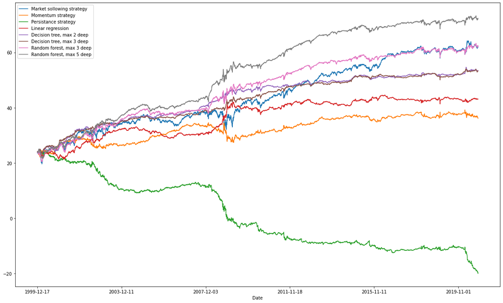

```python
portfolioDF.plot()
plt.show()
```